# Step 3: ATAC-Seq-Data-Analysis-QC on all cells

Step 3.2.1: Visualization of ATAC-seq-QC on all cells using ln(1+x) normalization

Xenia Sirodzha

2025-02-11

As the workflow for ATAC-seq QC was established in part 1, I performed this workflow on the entire data set. However, performing pseudo-bulking and normalization and subsequent visualization with the data from all cells is very computationally intensive. Therefore, visualization was performed separately from the pseudo-bulking and manual ln(1+x) normalization here.

# Libraries

These are the packages required for the code below.

```r
library(tidyverse)
library(binom)
library(lubridate)
library(broom)
library(scales) #for scale transformations
```

```r
library(cowplot) #arranging plots
library(ggpubr)
library(ggridges)
library(ggthemes) #stylising plots
library(ggplot2)
library(ggsci) #color palettes
library(readxl) #for loading excel files
library(Seurat) #for rna-seq data, atac-seq data
library(Signac) #for atac seq data
```

# 1 Data loading

For visualization, the manually normalized data set from “02-11-ATAC-Seq-Analysis-Step-3.1.1-log 1+x on all celltypes” was loaded into the session.

```r
readRDS("Data/psd.bulk.zfish_atac.lg1x.rds") -> psd.bulk.zfish_atac.lg1x
```

# 2 Data wrangling for visualization

After normalization, I prepared the data to plot with tidyverse. First, I converted the matrix to a data frame, then I calculated the values which were plotted as well (sum of pk_counts, coefficient of variance (cv)).

```r
#procedure
as.data.frame(psd.bulk.zfish_atac.lg1x)%>%
  pivot_longer(cols=!contains("rownames"), ,values_to = "pk_counts", names_to = "celltype") %>%
  mutate(pk_count_sum= sum(pk_counts)) %>%
  mutate(cv=sd(pk_counts) / mean(pk_counts)) %>%
  group_by(celltype) %>%
  mutate(pk_count_sum_celltype= sum(pk_counts)) %>%
  mutate(cv_celltype=sd(pk_counts) / mean(pk_counts)) %>%
  mutate(all="all celltypes")-> df_psd.bulk.zfish_atac.lg1x

#output
df_psd.bulk.zfish_atac.lg1x
```

| celltype | pk_counts | pk_count_sum | cv | pk_count_sum_celltype | cv_celltype | all |
| --- | --- | --- | --- | --- | --- | --- |
| anterior/posterior axis | 4.5963302 | 22403833 | 0.4421052 | 1131025.9 | 0.2699489 | all celltypes |
| blastomere | 2.4440070 | 22403833 | 0.4421052 | 467321.4 | 0.5634982 | all celltypes |
| central nervous system | 2.8343586 | 22403833 | 0.4421052 | 648820.7 | 0.3842393 | all celltypes |
| digestive system | 5.3242072 | 22403833 | 0.4421052 | 1257589.4 | 0.5343596 | all celltypes |
| epiblast | 2.0092128 | 22403833 | 0.4421052 | 430965.1 | 0.4998435 | all celltypes |
| erythroid lineage cell | 5.3305290 | 22403833 | 0.4421052 | 1162778.4 | 0.6015781 | all celltypes |
| EVL | 3.4400349 | 22403833 | 0.4421052 | 856580.3 | 0.3526425 | all celltypes |
| forebrain | 4.4096457 | 22403833 | 0.4421052 | 939902.7 | 0.3773245 | all celltypes |
| hypoblast | 2.6927161 | 22403833 | 0.4421052 | 608505.6 | 0.4126640 | all celltypes |
| immature eye | 4.3610020 | 22403833 | 0.4421052 | 888016.0 | 0.3690018 | all celltypes |

[output cut: 9990 more lines]

# 3 Visualization

Subsequently, the wrangled data was visualized analogous to the script in step 2 “02-06-ATAC-Seq-Analysis-Step-2.1 seurat norm”.

## 3.1 Histograms after pseudo-bulking by celltype

Then, the distribution of peaks overall and by celltype was visualized below.

```r
# all clusters
df_psd.bulk.zfish_atac.lg1x %>%
 ggplot(aes(x=pk_counts))+
 geom_histogram(binwidth = 0.2, color="gray15", alpha=0.5)+
 scale_y_continuous(breaks = scales::breaks_pretty(n=10))+
  coord_equal(ratio=2)+
  coord_fixed(ratio = 0.000075)+
  theme_bw()+ theme(text = element_text(size = 9, family="sans", color="black"), #stylisation
        axis.text = element_text(size=8, color="black"),
        axis.title=element_text(size=9, face = "bold"),
        plot.subtitle=element_text(size=10.5),
        plot.title=element_text(size=11, face = "bold"),
        legend.position ="none") ->dis.counts.1
```

```
## replace the existing one.
```

[figure not shown]

```r
#by celltype
 ggplot(df_psd.bulk.zfish_atac.lg1x, aes(x=pk_counts, fill = celltype))+
  geom_histogram(binwidth = 0.2, color="gray15", alpha=0.8)+
  scale_y_continuous(breaks = scales::breaks_pretty(n=5))+
  facet_wrap(facets = "celltype")+
  theme_bw()+ theme(text = element_text(size = 9, family="sans", color="black"), #stylisation
        axis.text = element_text(size=8, color="black"),
        axis.title=element_text(size=9, face = "bold"),
        plot.subtitle=element_text(size=10.5),
        plot.title=element_text(size=11, face = "bold"),
        legend.position ="none") ->dis.counts.cell.1

#side by side
dis.counts.1+dis.counts.cell.1
```

Apart from the digestive system cells and the erythroid lineage cells, all peaks in all celltypes are normally distributed.

## 3.2 Sum of all peaks

The sum of all peaks is 22,403,833.

```r
unique(df_psd.bulk.zfish_atac.lg1x$pk_count_sum)
```

```
## [1] 22403833
```

Then, the sum of all peaks overall and by celltype was visualized below.

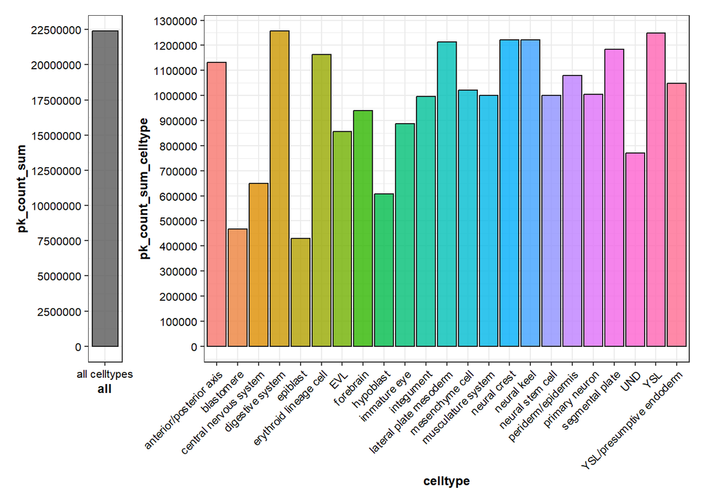

```r
# all clusters
df_psd.bulk.zfish_atac.lg1x %>%
  ungroup() %>%
  distinct(all, pk_count_sum) %>%
  ggplot(aes(x=all, y=pk_count_sum))+
  geom_col(alpha=0.8, color="gray10")+
  scale_y_continuous(n.breaks=10)+
  coord_fixed(ratio = 0.0000005)+
  theme_bw()+ theme(text = element_text(size = 9, family="sans", color="black"), #stylisation
        axis.text = element_text(size=8, color="black"),
        axis.title=element_text(size=9, face = "bold"),
        plot.subtitle=element_text(size=10.5),
        plot.title=element_text(size=11, face = "bold"),
        legend.position ="none") -> sum.peaks.all.1

# by cell type
df_psd.bulk.zfish_atac.lg1x %>%
  group_by(celltype) %>%
  distinct(pk_count_sum_celltype, pk_count_sum) %>%
  ggplot(aes(x=celltype, y=pk_count_sum_celltype, fill=celltype))+
  geom_col(alpha=0.8, color="gray10")+
   scale_y_continuous(n.breaks=20)+
  theme_bw()+ theme(text = element_text(size = 9, family="sans", color="black"), #stylisation
        axis.text = element_text(size=8, color="black"),
        axis.title=element_text(size=9, face = "bold"),
        axis.text.x = element_text(angle = 45, hjust = 1),
        plot.subtitle=element_text(size=10.5),
        plot.title=element_text(size=11, face = "bold"),
        legend.position ="none") -> sum.peaks.celltype.1

# side by side
sum.peaks.all.1|sum.peaks.celltype.1
```

## 3.4 Coefficient of variation

Next, the coefficient of variation was visualised in a bar plot.

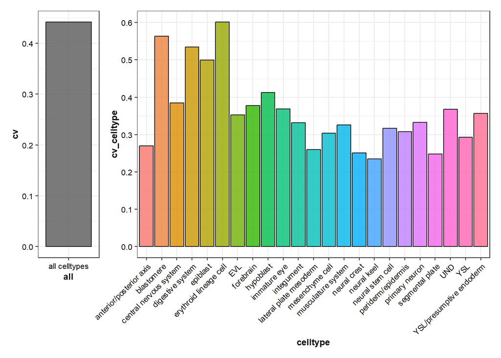

```r
df_psd.bulk.zfish_atac.lg1x %>%
  ungroup() %>%
  distinct(all, cv) %>%
  ggplot(aes(x=all, y=cv ))+
  geom_col(alpha=0.8, color="gray10")+
  scale_y_continuous(n.breaks=5)+
  coord_fixed(ratio = 10)+
  theme_bw()+ theme(text = element_text(size = 9, family="sans", color="black"), #stylisation
        axis.text = element_text(size=8, color="black"),
        axis.title=element_text(size=9, face = "bold"),
        plot.subtitle=element_text(size=10.5),
        plot.title=element_text(size=11, face = "bold"),
        legend.position ="none") -> cv.all.1

df_psd.bulk.zfish_atac.lg1x %>%
  group_by(celltype) %>%
  distinct(cv_celltype, cv) %>%
  ggplot(aes(x=celltype, y=cv_celltype, fill=celltype))+
  geom_col(alpha=0.8, color="gray10")+
  scale_y_continuous(n.breaks=10)+
  theme_bw()+ theme(text = element_text(size = 9, family="sans", color="black"), #stylisation
        axis.text = element_text(size=8, color="black"),
        axis.title=element_text(size=9, face = "bold"),
        axis.text.x = element_text(angle = 45, hjust = 1),
        plot.subtitle=element_text(size=10.5),
        plot.title=element_text(size=11, face = "bold"),
        legend.position ="none") ->cv.celltype.1

cv.all.1|cv.celltype.1
```

## 3.5 Count distribution visualized in a violin plot by cell type

Then, the count distribution was visualised with a violin plot as well as a violin plot with a boxplot drawn on top

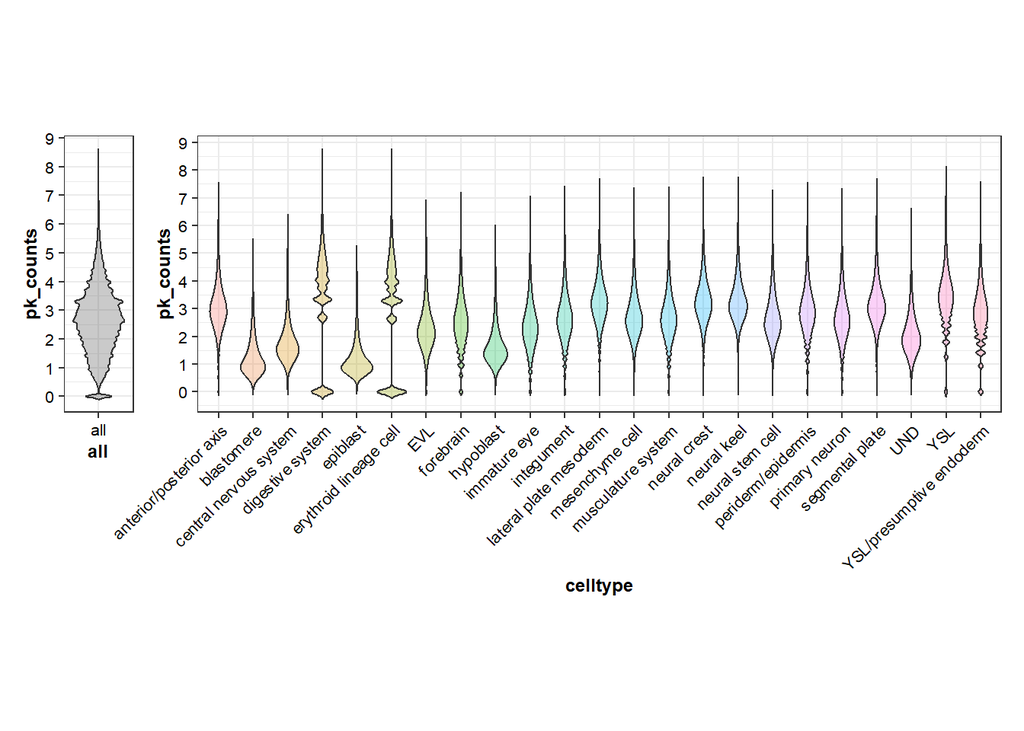

```r
df_psd.bulk.zfish_atac.lg1x %>%
  mutate(all="all") %>%
 ggplot( aes( x=all, y=pk_counts))+
  geom_violin(color="grey20", alpha=0.3, fill="gray30", trim=F)+
  scale_y_continuous(n.breaks=10)+
  coord_fixed(ratio = 0.5)+
  theme_bw()+ theme(text = element_text(size = 4, family="sans", color="black"), #stylisation
        axis.text = element_text(size=8, color="black"),
        axis.title=element_text(size=9, face = "bold"),
        plot.subtitle=element_text(size=10.5),
        plot.title=element_text(size=11, face = "bold"),
        legend.position ="none") -> v.plot.all.1


 ggplot(df_psd.bulk.zfish_atac.lg1x, aes(x=celltype, y=pk_counts, fill = celltype))+
  geom_violin(color="grey20", alpha=0.3, trim=F)+
   coord_equal(ratio = 0.8)+
   scale_y_continuous(n.breaks=10)+
  theme_bw()+ theme(text = element_text(size = 4, family="sans", color="black"), #stylisation
        axis.text = element_text(size=8, color="black"),
        axis.text.x = element_text(angle = 45, hjust = 1),
        axis.title=element_text(size=9, face = "bold"),
        plot.subtitle=element_text(size=10.5),
        plot.title=element_text(size=11, face = "bold"),
        legend.position ="none") -> v.plot.cells.1

# side by side
v.plot.all.1|v.plot.cells.1
```

The resulting plot can be seen down below.

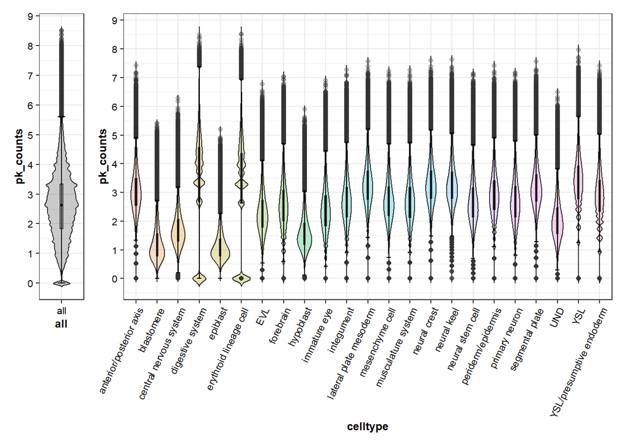

```r
df_psd.bulk.zfish_atac.lg1x %>%
  mutate(all="all") %>%
 ggplot( aes( x=all, y=pk_counts))+
  geom_violin(color="grey20", alpha=0.3, fill="gray30", trim=F)+
  geom_boxplot(width = 0.07, alpha=0.3)+
  stat_boxplot(geom ='errorbar', width=0.2, position=position_dodge(0.5))+
  scale_y_continuous(n.breaks=10)+
  coord_fixed(ratio = 0.8)+
  theme_bw()+ theme(text = element_text(size = 9, family="sans", color="black"), #stylisation
        axis.text = element_text(size=8, color="black"),
        axis.title=element_text(size=9, face = "bold"),
        plot.subtitle=element_text(size=10.5),
        plot.title=element_text(size=11, face = "bold"),
        legend.position ="none") -> v.plot.all.box.1


 ggplot(df_psd.bulk.zfish_atac.lg1x, aes(x=celltype, y=pk_counts, fill = celltype))+
  geom_violin(color="grey20", alpha=0.3, trim=F)+
  geom_boxplot(width = 0.07, alpha=0.3)+
  stat_boxplot(geom ='errorbar', width=0.2, position=position_dodge(0.5))+
   scale_y_continuous(n.breaks=10)+
  theme_bw()+ theme(text = element_text(size = 9, family="sans", color="black"), #stylisation
        axis.text = element_text(size=8, color="black"),
        axis.text.x = element_text(angle = 65, hjust = 1),
        axis.title=element_text(size=9, face = "bold"),
        plot.subtitle=element_text(size=10.5),
        plot.title=element_text(size=11, face = "bold"),
        legend.position ="none") -> v.plot.cells.box.1

 v.plot.all.box.1|v.plot.cells.box.1
```

Overall, most peak counts range from 0.5 to 5.6 and have a median of 2.6. This shows that this sample was normalized well.

To view the violin plots per cell type in more detail, the plots were displayed separately as well.

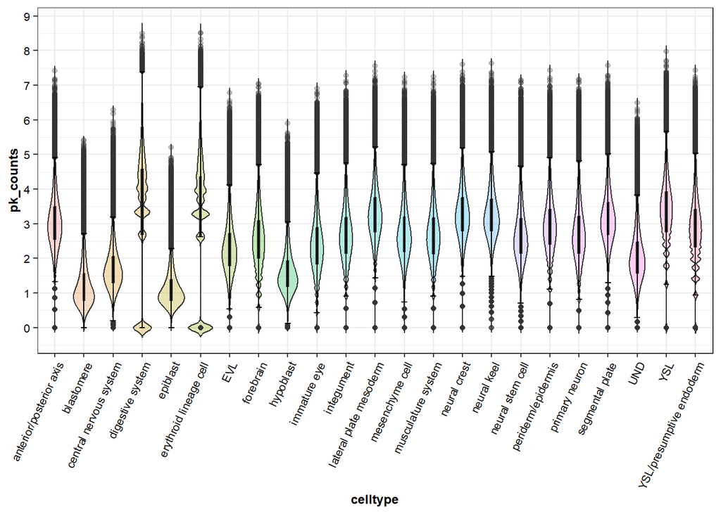

```r
v.plot.cells.box.1
```

To summarize, the values were normalized well by manual ln(1+x) transformation. In addition, digestive system and erythroid lineage cells are not normally distributed. Therefore, they are not as suitable for modelling as the other cell types.